# Preliminary Text-Analyses

Cristian Rodriguez

8/8/2019

# Data Structuring

The transcriptions were processed by separating each line of text, labeling pair, participant, topic, extension and medium. Different data structures were produced (word-level, intervention-level, person-level, pair-level, condition-level). For these results, all participant interventions were grouped and analyzed with the `liwc_alike()` function of the `quanteda` package. The word categories are identical to those from the LIWC software. Additionally, output scores (how responsive was your partner, how conflicted was the conversation, “how much mind” does your partner have) were appended for each participant, as well as the scores given by the conversation partner. Variables labeled as `alt_` indicate partner perception.

# Descriptives

| No | Variable | Stats / Values | Freqs (% of Valid) | Graph |
| --- | --- | --- | --- | --- |
| 1 | Medium [character] | 1. Audio 2. Text | 202 (49.8%) 204 (50.2%) |  |
| 2 | Extension [character] | 1. Long 2. Short | 206 (50.7%) 200 (49.3%) |  |
| 3 | Dehum [numeric] | Mean (sd) : 5.4 (0.9) min < med < max: 2.7 < 5.5 < 6.9 IQR (CV) : 1.3 (0.2) | 46 distinct values |  |
| 4 | Conflict [numeric] | Mean (sd) : 1.6 (1.2) min < med < max: 0 < 1.5 < 5.5 IQR (CV) : 2 (0.7) | 22 distinct values |  |
| 5 | Respons [numeric] | Mean (sd) : 4.5 (1.1) min < med < max: 0.8 < 4.8 < 6 IQR (CV) : 1.2 (0.2) | 22 distinct values |  |
| 6 | alt_Dehum [numeric] | Mean (sd) : 5.4 (0.9) min < med < max: 2.7 < 5.5 < 6.9 IQR (CV) : 1.3 (0.2) | 46 distinct values |  |
| 7 | alt_Conf [numeric] | Mean (sd) : 1.6 (1.2) min < med < max: 0 < 1.5 < 5.5 IQR (CV) : 2 (0.7) | 22 distinct values |  |
| 8 | alt_Resp [numeric] | Mean (sd) : 4.5 (1.1) min < med < max: 0.8 < 4.8 < 6 IQR (CV) : 1.2 (0.2) | 22 distinct values |  |
| 9 | function..function.words. [numeric] | Mean (sd) : 50.3 (4) min < med < max: 34.7 < 50.2 < 62.9 IQR (CV) : 5.2 (0.1) | 337 distinct values |  |
| 10 | affect..affect. [numeric] | Mean (sd) : 6 (1.8) min < med < max: 1.6 < 5.8 < 14.6 IQR (CV) : 2.1 (0.3) | 285 distinct values |  |
| 11 | social..social. [numeric] | Mean (sd) : 8.3 (2.8) min < med < max: 1.8 < 7.9 < 23.1 IQR (CV) : 3.1 (0.3) | 323 distinct values |  |
| 12 | cogproc..cognitive.processes. [numeric] | Mean (sd) : 15.1 (3.1) min < med < max: 0 < 15.1 < 25.4 IQR (CV) : 3.8 (0.2) | 345 distinct values |  |
| 13 | percept..perceptual.processes. [numeric] | Mean (sd) : 2.3 (1.6) min < med < max: 0 < 2 < 9.7 IQR (CV) : 1.9 (0.7) | 274 distinct values |  |
| 14 | bio..biological.processes. [numeric] | Mean (sd) : 1.7 (2) min < med < max: 0 < 0.7 < 9.8 IQR (CV) : 2.5 (1.2) | 218 distinct values |  |
| 15 | drives..drives. [numeric] | Mean (sd) : 6.5 (2.3) min < med < max: 0 < 6.1 < 20.6 IQR (CV) : 2.7 (0.4) | 313 distinct values |  |
| 16 | relativ..relativity. [numeric] | Mean (sd) : 8.2 (2.2) min < med < max: 2.6 < 8 < 14.7 IQR (CV) : 2.6 (0.3) | 306 distinct values |  |
| 17 | informal..informal.language. [numeric] | Mean (sd) : 2.7 (2.1) min < med < max: 0 < 2.1 < 13.7 IQR (CV) : 2.7 (0.8) | 279 distinct values |  |

## By Medium

Word categories by Medium

| Medium | Mind | Conflict | Responsiveness | Function | Affective | Social | Cognitive | Perceptual | Biological | Drives | Orientation | Informal |
| --- | --- | --- | --- | --- | --- | --- | --- | --- | --- | --- | --- | --- |
| Audio | 5.62 | 1.56 | 4.7 | 50.22 | 5.56 | 7.69 | 14.79 | 2.21 | 1.38 | 5.37 | 8.06 | 3.43 |
| Text | 5.27 | 1.67 | 4.3 | 50.39 | 6.35 | 8.86 | 15.41 | 2.47 | 2.03 | 7.56 | 8.32 | 1.88 |

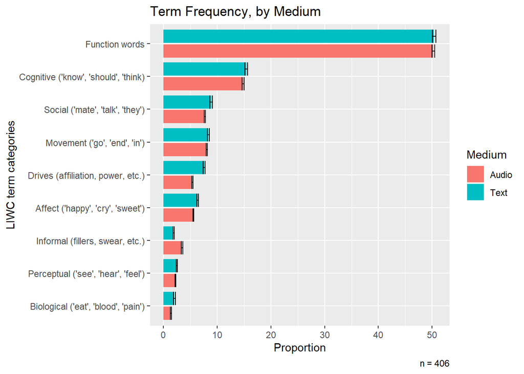

Audio minus Text (Negative estimates indicate higher values for Text)

Variable

t.stat

p.value

LL

UL

Cohens.D

Sig

Mind - attributed by partner

3.867

0.000

0.173

0.530

0.384

***

Conflict - attributed by partner

-0.924

0.356

-0.343

0.124

-0.092

Responsiveness - attributed by partner

3.728

0.000

0.191

0.617

0.370

***

Function words

-0.420

0.675

-0.958

0.621

-0.042

Affective words

-4.607

0.000

-1.119

-0.449

-0.457

***

Social words

-4.298

0.000

-1.711

-0.636

-0.427

***

Cognitive words

-2.009

0.045

-1.214

-0.013

-0.199

Perceptual words

-1.669

0.096

-0.576

0.047

-0.166

Biological words

-3.288

0.001

-1.041

-0.262

-0.326

Drive-related words

-10.790

0.000

-2.591

-1.792

-1.071

***

Relative words (space, time)

-1.212

0.226

-0.687

0.163

-0.120

Informal language

8.140

0.000

1.171

1.917

0.808

***

**Comments**: Higher mind (*t* =3.87,*d* = 0.38 and responsiveness (*t* =3.728,*d* = 0.37) attributed by partner in Audio over Text, but no differences in Conflict. Informal language is higher (*t* =8.14,*d* = 0.81) in Audio, whereas words related to affect (*t* =-4.61,*d* = -0.46), social relations (*t* =-4.3,*d* = -0.43), biological processes (*t* =-3.29,*d* = -0.33)and drives (affiliation, power, etc.; *t* =-10.79,*d* = -1.07) are more predominant in Text-based conversations.

## By Condition

Word categories by Extension

| Extension | Mind | Conflict | Responsiveness | Function | Affective | Social | Cognitive | Perceptual | Biological | Drives | Orientation | Informal |
| --- | --- | --- | --- | --- | --- | --- | --- | --- | --- | --- | --- | --- |
| Long | 5.42 | 1.71 | 4.52 | 50.43 | 5.97 | 7.94 | 15.16 | 2.28 | 1.76 | 6.26 | 8.16 | 2.73 |
| Short | 5.46 | 1.51 | 4.48 | 50.17 | 5.94 | 8.63 | 15.04 | 2.40 | 1.65 | 6.68 | 8.22 | 2.57 |

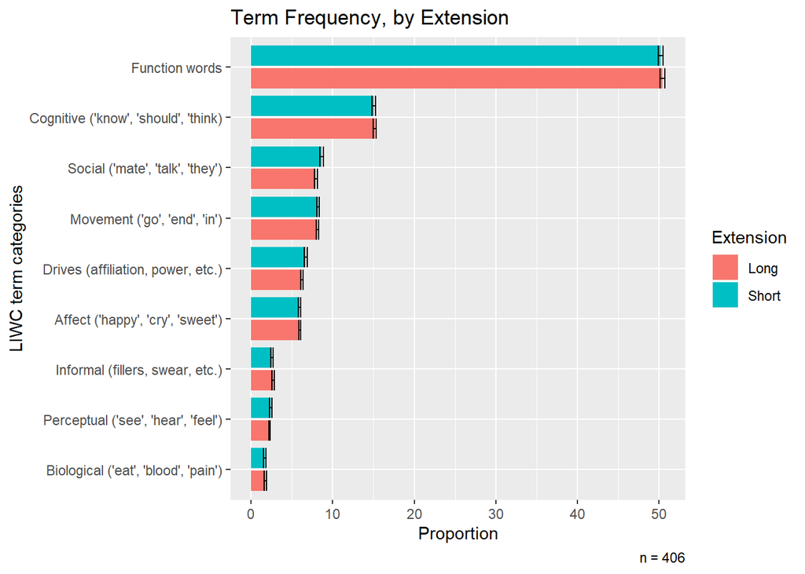

Long minus Short (Negative estimates indicate higher values for Short)

Variable

t.stat

p.value

LL

UL

Cohens.D

Sig

Mind - attributed by partner

-0.465

0.642

-0.225

0.139

-0.046

Conflict - attributed by partner

1.699

0.090

-0.032

0.434

0.169

Responsiveness - attributed by partner

0.424

0.672

-0.170

0.264

0.042

Function words

0.633

0.527

-0.536

1.045

0.063

Affective words

0.122

0.903

-0.324

0.366

0.012

Social words

-2.505

0.013

-1.246

-0.150

-0.249

Cognitive words

0.410

0.682

-0.480

0.734

0.041

Perceptual words

-0.726

0.468

-0.430

0.198

-0.072

Biological words

0.550

0.583

-0.285

0.507

0.055

Drive-related words

-1.844

0.066

-0.879

0.028

-0.183

Relative words (space, time)

-0.253

0.800

-0.483

0.373

-0.025

Informal language

0.775

0.439

-0.244

0.561

0.077

**Comments**: There are basically no significant differences among outcomes or language use between Short and Long conditions.

# Analyses

## Correlations

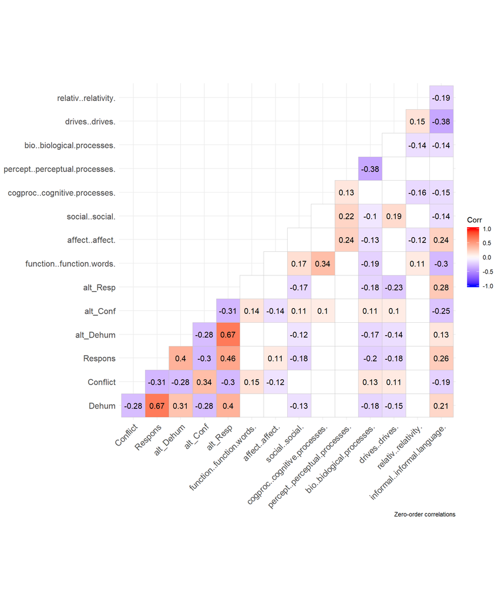

NOTE: blank spaces are non-significant correlations

**Comments**: Responsiveness, Conflict and Mind perceived by partner (`alt_Resp`, `alt_Conf`, and `alt_Dehum` respectively) are negatively associated with words related to Social relations, Biological Processes and Drives (positively for conflict); yet, positively associated with Informal language. Also perceived Conflict is associated with less affective words and more cognitive words.

## Linear Plots

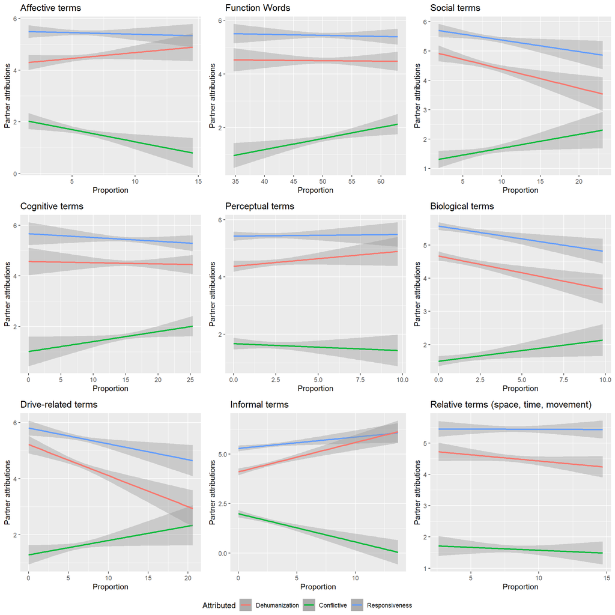

## Stepwise Regressions

For each one of the three partner perception outcomes, I ran a 10-fold crossvalidated stepwise regression model (ML approach to evaluate the linear model with best fit over 10 simulations). As predictors, all sub-categories of words were introduced - except for function words were excluded from the analyses, since they were not giving consistent results and are hard to intepret. The three best models generated are presented in this table. Only a few word-types are significant predictors of all three predictors.

**Regressions: best models of words predicting partner perception**

|  | Attributes perceived by partner |  |  |
| --- | --- | --- | --- |
|  | Responsiveness | Conflict | Mind |
| affect..affect..negemo..negative.emotions..anx..anx. | .35* (.19) |  |  |
| affect..affect..negemo..negative.emotions..anger..anger. | -.13 (.09) |  |  |
| affect..affect..negemo..negative.emotions..sad..sad. | -.55*** (.20) |  |  |
| social..social..female..female. | -.54** (.26) |  |  |
| affect..affect..posemo..positive.emotions. |  | -.16*** (.04) | .03 (.03) |
| cogproc..cognitive.processes..insight..insight. | .13*** (.04) | -.12*** (.05) | .05 (.04) |
| cogproc..cognitive.processes..cause..causal. | -.12*** (.04) |  | -.08** (.04) |
| percept..perceptual.processes..feel..feel. | .20** (.10) |  |  |
| cogproc..cognitive.processes..discrep..discrepancies. |  | .07 (.05) | .01 (.04) |
| cogproc..cognitive.processes..certain..certainty. |  | -.04 (.06) |  |
| cogproc..cognitive.processes..tentat..tentative. |  |  | .05 (.04) |
| drives..drives..achieve..achievement. | -.15** (.07) | .14* (.07) | -.22*** (.06) |
| drives..drives..power..power. |  |  | .01 (.04) |
| drives..drives..reward..reward. | .15* (.08) | -.11 (.08) | .14** (.07) |
| timeorient..time.orientation..focuspast..past.focus. | .08* (.04) |  |  |
| timeorient..time.orientation..focuspresent..present.focus. | -.05** (.02) | .11*** (.02) | -.05** (.02) |
| relativ..relativity..space..space. | -.03 (.03) |  |  |
| persconc..personal.concerns..relig..religion. | .33 (.24) |  |  |
| persconc..personal.concerns..home..home. |  |  | .08 (.17) |
| persconc..personal.concerns..death..death. | -.30* (.18) |  | .21 (.16) |
| informal..informal.language..swear..swear. |  |  | -.74** (.37) |
| persconc..personal.concerns..money..money. |  | -.08 (.06) | -.03 (.05) |
| informal..informal.language..assent..assent. | .18*** (.04) | -.16*** (.04) | .07* (.04) |
| informal..informal.language..filler..filler.words. |  |  | -.41 (.41) |
| Constant | 4.74*** (.45) | 1.44*** (.35) | 5.82*** (.33) |
| Observations | 406 | 406 | 406 |
| R<sup>2</sup> | .19 | .16 | .10 |
| Adjusted R<sup>2</sup> | .16 | .14 | .06 |
| Residual Std. Error | 1.02 (df = 390) | 1.11 (df = 396) | .90 (df = 390) |
| F Statistic | 6.05*** (df = 15; 390) | 8.43*** (df = 9; 396) | 2.74*** (df = 15; 390) |
| *Note:* | p<0.1; p<0.05; p<0.01 |  |  |